# Regressão

Rafael N. Magalhães

18 de abril, 2019

# Revisão dos conceitos básicos

Vimos na semana passada os conceitos de **associação**, **correlação** e **causalidade**, assim como vimos que a **regressão** é um tipo de análise que permite verificar a associação entre dois fenômenos mantendo constantes as variáveis de controle. Relembrando:

## Associação

Dizemos que duas variáveis estão associadas quando elas **variam conjuntamente**, tanto faz se na mesma direção ou em direções diferentes. Quando não há variação em uma das variáveis, não conseguimos, do ponto de vista estatistico, avaliar se há associaçao. **Variação é informação!**

$$cov(x, y) = \sum_{i=1}^{n}\frac{(x_{i} - \bar{x}) * (y_{i} - \bar{y})}{N}$$

## Correlação

O coeficiente **r de Pearson** é uma medida específica de associação, a mais conhecida entre diversas outras. É uma medida de covariância padronizada, de modo que os valores sempre são restritos entre -1 e 1. Esse coeficiente é linear por construção, e vai tentar traçar uma reta mesmo que a nuvem de dados tenha um formato não linear.

$$r = \sum_{i=1}^{n} \frac{cov(x,y)}{\sigma_{x}\sigma_{y}}$$

Quando encontramos associação entre duas variáveis, não conseguimos distinguir se:

- $X$ influencia $Y$
- $Y$ influencia $X$
- $X$ e $Y$ se influenciam mutuamente
- $Z$ influencia $X$ e $Y$ (variável omitida)

## Correlação e causalidade

Para concluir que

$$X \longrightarrow Y$$

precisamos estabelecer três condições:

- **Ordem temporal**: $Y$ não pode acontecer antes de $X$. É a condição de mais fácil verificação.
- **Associação**: $X$ e $Y$ devem variar mutuamente. Avaliada com as ferramentas que vimos até agora no curso.
- **Eliminação de alternativas**: todas as outras explicações plausíveis para $Y$ são descartadas. É a condição mais difícil de verificar.

# Afinal, o que significa “modelar” os dados?

Vamos começar com uma premissa bastante simples: para modelar, precisamos explicitar quais são as condições sob as quais uma variável $X$ se relaciona com uma variável $Y$. Para fins de nomenclatura, vamos começar a dar nomes específicos para essas variáveis:

- **Variável Dependente (VD)**: é o nosso fenômeno de interesse, usualmente denotada como $Y$
- **Variável Independente (VI)**: é o fenômeno que explica nossa variável dependente, que geralmente denotada como $X$

Matematicamente, vamos modelar $Y$ como uma *função* de $X$. Estatisticamente, a modelagem geralmente pode servir para dois objetivos principais:

1. **Predição**: usada para investigar a possibilidade de usar os valores de $X$ para prever o valor de $Y$. Não precisa haver uma conexão substantiva entre essas duas variáveis, contanto que uma sirva para gerar previsões confiáveis sobre os valores de outra.
2. **Explicação**: usada para entender a conexão e a significância (substantiva e estatística) da relação entre duas variáveis. Neste caso, queremos estimar com precisão o impacto de uma variável sobre a outra, de preferência excluindo as possíveis variáveis omitidas.

## Modelo linear

O modelo OLS permite verificar a associação entre dois fenômenos mantendo constantes outras explicações possíveis, que chamamos de variáveis de controle. Trata-se de um **modelo linear**, mas veremos como flexibilizar essa suposição logo mais. Por enquanto, cabe lembrar que a forma funcional da regressão nada mais é do que uma equação:

$$y = \beta{_0} + \beta{_1} x{_1} + \ldots + \beta{_k} x{_k} + \epsilon$$

Nessa equação, os valores de $y$ e de $x_{1} \ldots x{_k}$ são conhecidos, e os valores de $\beta_{0} \ldots \beta_{k}$ são as incógnitas. Quando temos apenas uma variável independente, podemos estimar o valor de $\beta$ de maneira simples:

$$\hat{\beta} = \frac{\sum_{i=1}^{n}(x_{i} - \bar{x})(y_{i} - \bar{y})}{\sum_{i=1}^{n}(x_{i} - \bar{x})^{2}}$$

Geralmente, porém, temos um conjunto de variáveis independentes, com muito mais incógnitas. Nesses casos, precisamos resolver um sistema de equações:

$$\boldsymbol{\hat{\beta}} = (X^{\prime}X)^{-1}X^{\prime}y$$

Vamos voltar ao banco de dados do TSE que utilizamos na semana passada para explorar um pouco mais as possibilidades da análise de regressão, assim como suas limitações.

# Base de dados - Eleições 2018

## Observações iniciais

Vamos fazer dois tipos de análise: uma que considera os fatores que fazem com que um candidato tenha **mais votos**, e outra que se concentra nos fatores que fazem com que um candidato sela **eleito**. São dois fenômenos similares, mas uma diferença pequena na natureza dessas variáveis vai ter consequências relevantes na modelagem.

Vamos levar em consideração apenas as variáveis que já existem no ou que podem ser calculadas diretamente com o banco de dados do TSE. Uma análise mais completa envolveria a coleta de mais variáveis e/ou maior reflexão sobre o desenho da análise, mas nosso objetivo aqui é fazer um exercício sobre as possibilidades da análise de regressão.

## Carregando e transformando a base de dados

```r
library(tidyverse)
library(cepespR)

# Identificar deputados eleitos em 2014, para saber quem são os incumbentes em 2018
eleitos_2014 <- get_elections(year = 2014,
                              position = "Deputado Federal",
                              regional_aggregation = "Estado",
                              political_aggregation = "Candidato") %>%
  mutate(RESULTADO = case_when(DESC_SIT_TOT_TURNO == "ELEITO POR QP" | DESC_SIT_TOT_TURNO == "ELEITO POR MEDIA" ~ "Eleito",
                               TRUE ~ "Não Eleito")) %>%
  filter(RESULTADO == "Eleito") %>%
  select(CPF_CANDIDATO)

# Carregar candidaturas de 2018 e criar novas variáveis
candidatos_2018 <- get_elections(year = 2018,
                                 position = "Deputado Federal",
                                 regional_aggregation = "Estado",
                                 political_aggregation = "Candidato") %>%
  # Selecionar apenas candidaturas homologadas
  filter(DES_SITUACAO_CANDIDATURA == "APTO") %>%
  # Criar variáveis de Incumbência e Resultado
  mutate(INCUMBENTE = case_when(CPF_CANDIDATO %in% eleitos_2014$CPF_CANDIDATO ~ "Sim",
                               TRUE ~ "Não"),
         RESULTADO = case_when(DESC_SIT_TOT_TURNO == "ELEITO POR QP" | DESC_SIT_TOT_TURNO == "ELEITO POR MEDIA" ~ "Eleito",
                               TRUE ~ "Não Eleito"),
         VEREADOR = case_when(DESCRICAO_OCUPACAO == "VEREADOR" ~ "Sim",
                               TRUE ~ "Não"),
         EMPRESARIO = case_when(DESCRICAO_OCUPACAO == "EMPRESÁRIO" ~ "Sim",
                               TRUE ~ "Não"),
         E_SUPERIOR = case_when(DESCRICAO_GRAU_INSTRUCAO == "SUPERIOR COMPLETO" ~ "Sim",
                               TRUE ~ "Não"),
         RACA = case_when(DESCRICAO_COR_RACA == "BRANCA" ~ "Branco",
                              TRUE ~ "Não branco")) %>%
  # Deixar no banco apenas as variáveis que nos interessam
  select(c("UF",
           "INCUMBENTE",
           "NOME_URNA_CANDIDATO",
           "SIGLA_PARTIDO",
           "DES_SITUACAO_CANDIDATURA",
           "DESCRICAO_OCUPACAO",
           "IDADE_DATA_ELEICAO",
           "DESCRICAO_SEXO",
           "DESCRICAO_GRAU_INSTRUCAO",
           "DESCRICAO_ESTADO_CIVIL",
           "DESCRICAO_COR_RACA",
           "DESC_SIT_TOT_TURNO",
           "VEREADOR",
           "EMPRESARIO",
           "E_SUPERIOR",
           "RACA",
           "RESULTADO",
           "QTDE_VOTOS")) %>%
    # Calcular o percentual de votos de cada candidato
    group_by(UF) %>%
    mutate(VOTOS_VALIDOS = sum(QTDE_VOTOS)) %>%
    ungroup() %>%
    mutate(VOTOS_PERC = QTDE_VOTOS/VOTOS_VALIDOS*100)
```

## Categorias de referência

Vamos definir as categorias de referência de cada variável, de modo que todas as estimativas que obtivermos sejam comparações substantivamente interessantes.

Esse passo não é obrigatório, e a categoria de referência é uma escolha arbitrária do analista, de acordo com o julgamento que se faz sobre qual é a quantidade de interesse mais relevante.

```r
candidatos_2018 <- candidatos_2018 %>%
  mutate(INCUMBENTE = relevel(factor(INCUMBENTE), ref = "Não"),
         DESCRICAO_ESTADO_CIVIL = relevel(factor(DESCRICAO_ESTADO_CIVIL), ref = "SOLTEIRO(A)"),
         DESCRICAO_SEXO = relevel(factor(DESCRICAO_SEXO), ref = "MASCULINO"),
         DESCRICAO_COR_RACA = relevel(factor(DESCRICAO_COR_RACA), ref = "BRANCA"),
         VEREADOR = relevel(factor(VEREADOR), ref = "Não"),
         EMPRESARIO = relevel(factor(EMPRESARIO), ref = "Não"),
         E_SUPERIOR = relevel(factor(E_SUPERIOR), ref = "Não"),
         RESULTADO = relevel(factor(RESULTADO), ref = "Não Eleito"),
         RACA = relevel(factor(RACA), ref = "Branco"))
```

## Base final

| UF | INCUMBENTE | NOME_URNA_CANDIDATO | SIGLA_PARTIDO | DES_SITUACAO_CANDIDATURA | DESCRICAO_OCUPACAO | IDADE_DATA_ELEICAO | DESCRICAO_SEXO | DESCRICAO_GRAU_INSTRUCAO | DESCRICAO_ESTADO_CIVIL | DESCRICAO_COR_RACA | DESC_SIT_TOT_TURNO | VEREADOR | EMPRESARIO | E_SUPERIOR | RACA | RESULTADO | QTDE_VOTOS | VOTOS_VALIDOS | VOTOS_PERC |
| --- | --- | --- | --- | --- | --- | --- | --- | --- | --- | --- | --- | --- | --- | --- | --- | --- | --- | --- | --- |
| AC | Não | PAULINHA | AVANTE | APTO | ESTUDANTE, BOLSISTA, ESTAGIÁRIO E ASSEMELHADOS | 24 | FEMININO | ENSINO MÉDIO INCOMPLETO | SOLTEIRO(A) | BRANCA | NÃO ELEITO | Não | Não | Não | Branco | Não Eleito | 6 | 398133 | 1.507034e-03 |
| AC | Não | PROFESSOR CEZAR HILDO | AVANTE | APTO | OUTROS | 39 | MASCULINO | SUPERIOR COMPLETO | CASADO(A) | PARDA | NÃO ELEITO | Não | Não | Sim | Não branco | Não Eleito | 64 | 398133 | 1.607503e-02 |
| AC | Não | DANILO MEDEIROS | AVANTE | APTO | OUTROS | 30 | MASCULINO | SUPERIOR COMPLETO | SOLTEIRO(A) | BRANCA | NÃO ELEITO | Não | Não | Sim | Branco | Não Eleito | 186 | 398133 | 4.671806e-02 |
| AC | Não | ELDO PONTES | AVANTE | APTO | EMPRESÁRIO | 54 | MASCULINO | SUPERIOR COMPLETO | CASADO(A) | PARDA | NÃO ELEITO | Não | Sim | Sim | Não branco | Não Eleito | 36 | 398133 | 9.042204e-03 |
| AC | Não | PEREIRA BOMBOM | AVANTE | APTO | MOTOBOY | 36 | MASCULINO | ENSINO MÉDIO COMPLETO | DIVORCIADO(A) | PARDA | NÃO ELEITO | Não | Não | Não | Não branco | Não Eleito | 87 | 398133 | 2.185199e-02 |
| AC | Não | MATIAS MORAIS | AVANTE | APTO | OUTROS | 44 | MASCULINO | ENSINO MÉDIO COMPLETO | CASADO(A) | PARDA | NÃO ELEITO | Não | Não | Não | Não branco | Não Eleito | 10 | 398133 | 2.511723e-03 |
| AC | Não | LENO | AVANTE | APTO | OUTROS | 47 | MASCULINO | SUPERIOR COMPLETO | CASADO(A) | PARDA | NÃO ELEITO | Não | Não | Sim | Não branco | Não Eleito | 33 | 398133 | 8.288687e-03 |
| AC | Não | PROFESSORA MARIA PEREGRINA | AVANTE | APTO | APOSENTADO (EXCETO SERVIDOR PÚBLICO) | 57 | FEMININO | SUPERIOR COMPLETO | CASADO(A) | PARDA | NÃO ELEITO | Não | Não | Sim | Não branco | Não Eleito | 67 | 398133 | 1.682855e-02 |
| AC | Não | TATY | AVANTE | APTO | ESTUDANTE, BOLSISTA, ESTAGIÁRIO E ASSEMELHADOS | 21 | FEMININO | ENSINO MÉDIO INCOMPLETO | SOLTEIRO(A) | PARDA | NÃO ELEITO | Não | Não | Não | Não branco | Não Eleito | 14 | 398133 | 3.516413e-03 |
| AC | Não | ANDRESA BARROS | DC | APTO | EMPRESÁRIO | 39 | FEMININO | ENSINO MÉDIO COMPLETO | CASADO(A) | PARDA | SUPLENTE | Não | Sim | Não | Não branco | Não Eleito | 355 | 398133 | 8.916618e-02 |

[output cut: 7823 more lines]

# Análises OLS

## Modelo bivariado

Vamos começar com um modelo linear bivariado, estimando o efeito de ser mulher sobre a quantidade de votos da candidata. Portanto, estimaremos o seguinte modelo:

$$\widehat{votos} = \beta{_0} + \beta{_1} sexo + \epsilon$$

```r
library(moderndive)

m_biv <- lm(QTDE_VOTOS ~ DESCRICAO_SEXO, data = candidatos_2018)
get_regression_table(m_biv)
```

| term | estimate | std_error | statistic | p_value | lower_ci | upper_ci |
| --- | --- | --- | --- | --- | --- | --- |
| intercept | 14485.352 | 521.133 | 27.796 | 0 | 13463.79 | 15506.911 |
| DESCRICAO_SEXOFEMININO | -8483.491 | 927.659 | -9.145 | 0 | -10301.95 | -6665.032 |

Lembre-se que o terceiro critério para avaliar causalidade é a eliminação de todas as explicações alternativas, mas nesse modelo *não estamos controlando por mais nada*. Podemos dar passos na direção certa incluindo mais controles em um **modelo multivariado**.

*Nota: Uma controle simples que já poderíamos utilizar mesmo em uma regressão bivariada é considerar a população. Obviamente, estados mais populosos terão mais votos, o que pode fazer com que a simples contagem dos números absolutos não tenha muito sentido. Daqui para a frente, vamos utilizar o **percentual de votos** como variável dependente*

```r
summary(candidatos_2018$VOTOS_PERC)
```

```
##      Min.   1st Qu.    Median      Mean   3rd Qu.      Max.
##  0.000036  0.006916  0.027413  0.344696  0.164590 13.146788
```

## Modelo multivariado

Vamos tratar agora de um modelo mais interessante:

$$\widehat{votos} = \beta{_0} + \beta{_1} sexo + \beta{_2} raca + \epsilon$$

```r
m_mult <- lm(VOTOS_PERC ~ DESCRICAO_SEXO + RACA, data = candidatos_2018)
get_regression_table(m_mult)
```

| term | estimate | std_error | statistic | p_value | lower_ci | upper_ci |
| --- | --- | --- | --- | --- | --- | --- |
| intercept | 0.451 | 0.016 | 27.625 | 0 | 0.419 | 0.483 |
| DESCRICAO_SEXOFEMININO | -0.212 | 0.024 | -8.830 | 0 | -0.259 | -0.165 |
| RACANão branco | -0.094 | 0.023 | -4.174 | 0 | -0.138 | -0.050 |

Com mais variáveis, fica mais interessante visualizar os resultados:

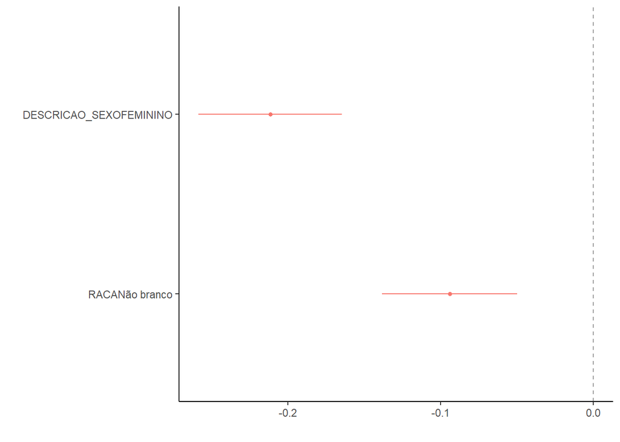

```r
# install.packages("dotwhisker")
library(dotwhisker)

m_mult %>% dwplot() +
  geom_vline(xintercept = 0, colour = "grey60", linetype = 2) +
  theme_classic() +
  theme(legend.position = "none")
```

## Interações

Vimos que mulheres ganham menos votos, assim como negros. Para avaliar o impacto para as mulheres negras, fazemos uma interação entre as variáveis, estimando o seguinte modelo:

$$\widehat{votos} = \beta{_0} + \beta{_1} sexo + \beta{_2} raca + \beta{_3}sexo* raca + \epsilon$$

```r
m_int <- lm(VOTOS_PERC ~ DESCRICAO_SEXO + RACA + DESCRICAO_SEXO:RACA,
            data = candidatos_2018)
get_regression_table(m_int)
```

| term | estimate | std_error | statistic | p_value | lower_ci | upper_ci |
| --- | --- | --- | --- | --- | --- | --- |
| intercept | 0.450 | 0.018 | 25.698 | 0.000 | 0.416 | 0.485 |
| DESCRICAO_SEXOFEMININO | -0.209 | 0.032 | -6.557 | 0.000 | -0.271 | -0.147 |
| RACANão branco | -0.092 | 0.027 | -3.372 | 0.001 | -0.146 | -0.039 |
| DESCRICAO_SEXOFEMININO:RACANão branco | -0.006 | 0.048 | -0.122 | 0.903 | -0.101 | 0.089 |

Termos interativos tornam a interpretação um pouco mais difícil, então vamos passo-a-passo:

- **Homens brancos** terão, em média, $0,45\%$ dos votos ($\beta_{0}$)
- **Homens negros** terão, em média $0,45 - 0,092 = 0,36\%$ dos votos ($\beta_{0} + \beta_{2}$)
- **Mulheres brancas** terão, em média, $0,45 - 0,209 = 0,24\%$ dos votos ($\beta_{0} + \beta_{1}$)
- **Mulheres negras** terão, em média, $0,45 - 0,092 - 0,209 - 0,006 = 0,14\%$ dos votos ($\beta_{0} + \beta_{1} + \beta_{2} + \beta_{3}$)

Note que o efeito da interação, em si, não é significativo (por quê?)

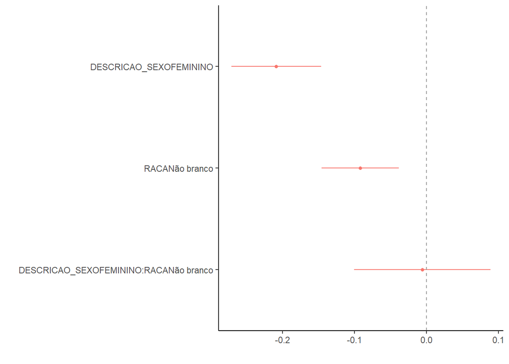

```r
m_int %>% dwplot() +
  geom_vline(xintercept = 0, colour = "grey60", linetype = 2) +
  theme_classic() +
  theme(legend.position = "none")
```

## Modelo completo

Agora, temos as ferramentas para interpretar um modelo mais completo:

```r
m_compl <- lm(VOTOS_PERC ~ DESCRICAO_SEXO + RACA + DESCRICAO_SEXO:RACA + DESCRICAO_ESTADO_CIVIL + VEREADOR + EMPRESARIO + E_SUPERIOR + factor(UF),
            data = candidatos_2018)
get_regression_table(m_compl)
```

| term | estimate | std_error | statistic | p_value | lower_ci | upper_ci |
| --- | --- | --- | --- | --- | --- | --- |
| intercept | 1.164 | 0.105 | 11.066 | 0.000 | 0.958 | 1.371 |
| DESCRICAO_SEXOFEMININO | -0.198 | 0.030 | -6.556 | 0.000 | -0.257 | -0.139 |
| RACANão branco | -0.179 | 0.027 | -6.632 | 0.000 | -0.232 | -0.126 |
| DESCRICAO_ESTADO_CIVILCASADO(A) | 0.150 | 0.024 | 6.242 | 0.000 | 0.103 | 0.197 |
| DESCRICAO_ESTADO_CIVILDIVORCIADO(A) | 0.036 | 0.036 | 1.001 | 0.317 | -0.034 | 0.106 |
| DESCRICAO_ESTADO_CIVILSEPARADO(A) JUDICIALMENTE | -0.072 | 0.097 | -0.739 | 0.460 | -0.263 | 0.119 |
| DESCRICAO_ESTADO_CIVILVIÚVO(A) | 0.030 | 0.085 | 0.352 | 0.725 | -0.137 | 0.197 |
| VEREADORSim | 0.063 | 0.058 | 1.071 | 0.284 | -0.052 | 0.177 |
| EMPRESARIOSim | 0.023 | 0.035 | 0.677 | 0.498 | -0.044 | 0.091 |
| E_SUPERIORSim | 0.240 | 0.022 | 11.089 | 0.000 | 0.198 | 0.283 |

[output cut: 27 more lines]

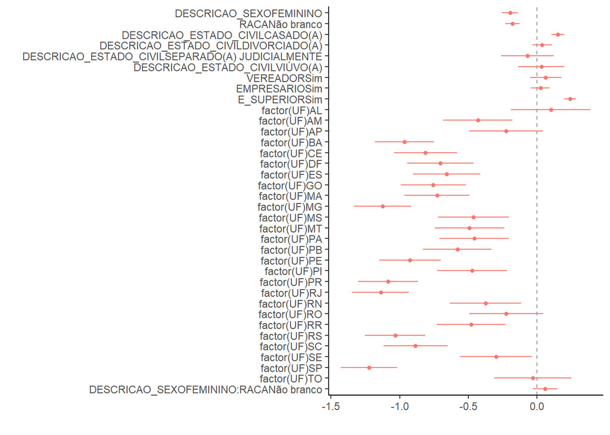

```r
m_compl %>% dwplot() +
  geom_vline(xintercept = 0, colour = "grey60", linetype = 2) +
  theme_classic() +
  theme(legend.position = "none")
```

# Modelo Logit

Modelos logit são utilizados para variáveis dependentes binárias. Esse é o caso, por exemplo, da variável `RESULTADOS`, cujos resultados são *Eleito* ou *Não Eleito*.

É uma mudança pequena, mas a forma funcional do modelo é completamente diferente da do modelo OLS. A probabilidade de que $Y = 1$ é dada por:

$$\frac{1}{1 + e^{-(\beta{_0} + \beta{_1} x{_1} + \ldots + \beta{_k} x{_k})}}$$

## Estimação

```r
m_logit <- glm(RESULTADO ~ DESCRICAO_SEXO + RACA + DESCRICAO_SEXO:RACA + DESCRICAO_ESTADO_CIVIL + VEREADOR + EMPRESARIO + E_SUPERIOR + factor(UF),
            data = candidatos_2018,
            family = "binomial")
get_regression_table(m_compl)
```

| term | estimate | std_error | statistic | p_value | lower_ci | upper_ci |
| --- | --- | --- | --- | --- | --- | --- |
| intercept | 1.164 | 0.105 | 11.066 | 0.000 | 0.958 | 1.371 |
| DESCRICAO_SEXOFEMININO | -0.198 | 0.030 | -6.556 | 0.000 | -0.257 | -0.139 |
| RACANão branco | -0.179 | 0.027 | -6.632 | 0.000 | -0.232 | -0.126 |
| DESCRICAO_ESTADO_CIVILCASADO(A) | 0.150 | 0.024 | 6.242 | 0.000 | 0.103 | 0.197 |
| DESCRICAO_ESTADO_CIVILDIVORCIADO(A) | 0.036 | 0.036 | 1.001 | 0.317 | -0.034 | 0.106 |
| DESCRICAO_ESTADO_CIVILSEPARADO(A) JUDICIALMENTE | -0.072 | 0.097 | -0.739 | 0.460 | -0.263 | 0.119 |
| DESCRICAO_ESTADO_CIVILVIÚVO(A) | 0.030 | 0.085 | 0.352 | 0.725 | -0.137 | 0.197 |
| VEREADORSim | 0.063 | 0.058 | 1.071 | 0.284 | -0.052 | 0.177 |
| EMPRESARIOSim | 0.023 | 0.035 | 0.677 | 0.498 | -0.044 | 0.091 |
| E_SUPERIORSim | 0.240 | 0.022 | 11.089 | 0.000 | 0.198 | 0.283 |

[output cut: 27 more lines]

## Interpretação

A interpretação de modelos logit é mais complicada do que a do modelo linear, envolvendo conceitos que ainda não vimos (como *log odds* e razão de chance). Por enquanto, vamos ficar com uma regrinha que aproxima bem os resultados.